# Seventh Week: Generalized Linear Models

Murder or suicide

Mina Moosavi - 93106788

2018-04-28 02:46:09

[figure not shown]

> با توجه به سوالات مرگ و میر در آمریکا به سوالات زیر پاسخ دهید.

بارگزاری داده ها و کتابخانه ها:

```r
library(readxl)
library(dplyr)

death = read.csv("data/murder_suicide.csv")
```

۱. از میان متغیرهای داده مرگ و میر یک زیرمجموعه ایی بدون حشو در نظر بگیرید. ماتریس همبستگی متغیرهای مختلف را به دست آورده و سپس رسم نمایید. علاوه بر این نمودار پراکنش متغیرهای انتخاب شده را همزمان نسبت به هم رسم نمایید.

ابتدا داده هایی که عددی نیستند را تبدیل به عدد می کنیم. سپس داده های عددی را انتخاب می کنیم. برای بدست آوردن متغیر های حشو، ابتدا ماتریس همبستگی متغیرها را رسم می کنیم و داده هایی که بیشترین همبستگی را با یکدیگر دارند، بررسی می کنیم. در دسته هایی که یک متغیر به روش های مختلف ارزیابی شده اند، هر بار یکی را قرار داده و متغیری که بیشترین هم بستگی را داشته باشد را انتخاب می کنیم. در نهایت نمودار همبستگی ما به صورت زیر می شود که مشاهده می کنیم داده ی حشو دیگر نداریم.

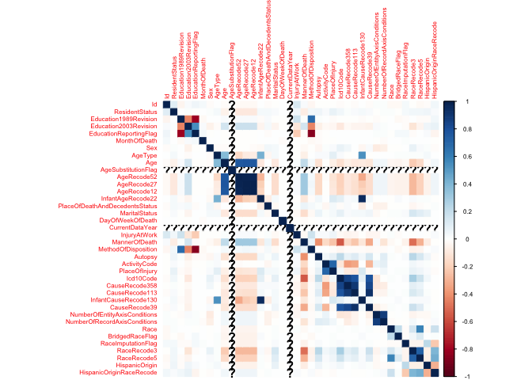

```r
library(corrplot)

death_num <- death %>% mutate(Sex = factor(Sex) ) %>%
  mutate(MannerOfDeath = ifelse(MannerOfDeath == 2, 1, 0)) %>%
  mutate(InjuryAtWork = factor(InjuryAtWork)) %>%
  mutate(MethodOfDisposition = factor(MethodOfDisposition)) %>%
  mutate(MaritalStatus = factor(MaritalStatus))

all_cors = cor(data.matrix(death_num))
corrplot(all_cors, method = "color", tl.cex = 0.5/par("cex"), cl.cex = 0.5/par("cex"))
```

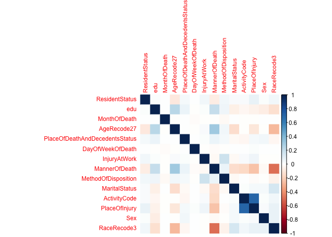

```r
#### fixing education
death_num1989 <- death_num %>% filter(EducationReportingFlag == 0) %>%
  mutate(edu = ifelse(Education1989Revision == 10, 2, ifelse(
    Education1989Revision == 11, 2, ifelse(
      Education1989Revision == 12, 3, ifelse(
        Education1989Revision == 13, 4, ifelse(
          Education1989Revision == 14, 5, ifelse(
            Education1989Revision == 15, 5, ifelse(
              Education1989Revision == 16, 6, ifelse(
                Education1989Revision == 17, 7, ifelse(
                  Education1989Revision == 99, 9, ifelse(
                    Education1989Revision == 9, 2, 1
                  )
                )
              )
            )
          )
        )
      )
    )))) %>% select(-EducationReportingFlag, -Education1989Revision, -Education2003Revision)

death_num2003 <- death_num %>% filter(EducationReportingFlag == 1) %>%
  rename(edu = Education2003Revision) %>% select(-EducationReportingFlag, -Education1989Revision)

death_num2003$edu <- ifelse(death_num2003$edu == 8, 7, death_num2003$edu)

death_num <- rbind(death_num2003, death_num1989)

#### selecting data
death_num <- death_num %>% select(ResidentStatus, edu, MonthOfDeath, AgeRecode27, PlaceOfDeathAndDecedentsStatus,
                                  DayOfWeekOfDeath, InjuryAtWork, MannerOfDeath, MethodOfDisposition, MaritalStatus,
                                  ActivityCode, PlaceOfInjury, Sex, RaceRecode3)
death_num_new <- death_num

all_cors = cor(data.matrix(death_num))
corrplot(all_cors, method = "color", tl.cex = 0.75/par("cex"), cl.cex = 0.75/par("cex"))
```

هم چنین میزان همبستگی متغیرها را با متغیر MannerOfDeath بدست می آوریم.

```r
knitr::kable(sort(abs(all_cors['MannerOfDeath',]), decreasing = TRUE)[2:14])
```

|  | x |
| --- | --- |
| RaceRecode3 | 0.4968254 |
| AgeRecode27 | 0.3058915 |
| PlaceOfInjury | 0.2431710 |
| edu | 0.2065287 |
| ActivityCode | 0.1650709 |
| MaritalStatus | 0.1424127 |
| ResidentStatus | 0.0737889 |
| MethodOfDisposition | 0.0621357 |
| PlaceOfDeathAndDecedentsStatus | 0.0615197 |
| InjuryAtWork | 0.0229571 |
| Sex | 0.0200664 |
| DayOfWeekOfDeath | 0.0108975 |
| MonthOfDeath | 0.0067005 |

از آنجایی که تعداد داده ها بسیار زیاد است و باعث کندی نمایش scatterplotmatrix می شود، این نمودار را بر اساس تعداد کمتری از داده ها رسم می کینم. نمودار پراکنش متغیرها نیز به شکل زیر است:

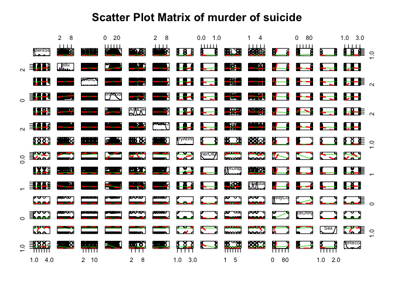

```r
library(car)

death_num_sample = sample_n(death_num, 2000)
scatterplotMatrix(death_num_sample, spread=FALSE, smoother.args=list(lty=2),
                  main="Scatter Plot Matrix of murder of suicide")
```

۲. اثر هر یک از متغیرهای جنسیت، نژاد،آموزش، سن و نحوه تدفین را بر مرگ یا خودکشی ارزیابی کنید.

با توجه به نوع داده ها(که دارای لول های مختلف هستند) از دو تست correlation و chi square test of independence استفاده می کنیم.

```r
death_mat <- data.matrix(death_num)

cor.test(death_mat[,"Sex"], death_mat[,"MannerOfDeath"], method = 'spearman')
```

```
    Spearman's rank correlation rho

data:  death_mat[, "Sex"] and death_mat[, "MannerOfDeath"]
S = 3.6684e+13, p-value = 8.888e-07
alternative hypothesis: true rho is not equal to 0
sample estimates:
       rho
-0.0200664
```

```r
chisq.test(death_num$Sex, death_num$MannerOfDeath)
```

```
    Pearson's Chi-squared test with Yates' continuity correction

data:  death_num$Sex and death_num$MannerOfDeath
X-squared = 24.044, df = 1, p-value = 9.417e-07
```

بر اساس این دو تست مشاهده می کنیم که این دو متغیر با یکدیگر ارتباط داشته و از هم مستقل نیستند.

```r
cor.test(death_mat [,"RaceRecode3"], death_mat [,"MannerOfDeath"], method = 'spearman')
```

```
    Spearman's rank correlation rho

data:  death_mat[, "RaceRecode3"] and death_mat[, "MannerOfDeath"]
S = 5.322e+13, p-value < 2.2e-16
alternative hypothesis: true rho is not equal to 0
sample estimates:
       rho
-0.4798949
```

```r
chisq.test(death_num$RaceRecode3, death_num$MannerOfDeath)
```

```
    Pearson's Chi-squared test

data:  death_num$RaceRecode3 and death_num$MannerOfDeath
X-squared = 15243, df = 2, p-value < 2.2e-16
```

بر اساس این دو تست مشاهده می کنیم که این دو متغیر با یکدیگر ارتباط داشته و از هم مستقل نیستند.

```r
cor.test(death_mat [,"edu"], death_mat [,"MannerOfDeath"], method = 'spearman')
```

```
    Spearman's rank correlation rho

data:  death_mat[, "edu"] and death_mat[, "MannerOfDeath"]
S = 2.747e+13, p-value < 2.2e-16
alternative hypothesis: true rho is not equal to 0
sample estimates:
      rho
0.2361407
```

```r
chisq.test(death_num$edu, death_num$MannerOfDeath)
```

```
    Pearson's Chi-squared test

data:  death_num$edu and death_num$MannerOfDeath
X-squared = 3825, df = 7, p-value < 2.2e-16
```

بر اساس این دو تست مشاهده می کنیم که این دو متغیر با یکدیگر ارتباط داشته و از هم مستقل نیستند.

```r
cor.test(death_mat [,"AgeRecode27"], death_mat [,"MannerOfDeath"], method = 'spearman')
```

```
    Spearman's rank correlation rho

data:  death_mat[, "AgeRecode27"] and death_mat[, "MannerOfDeath"]
S = 2.5089e+13, p-value < 2.2e-16
alternative hypothesis: true rho is not equal to 0
sample estimates:
     rho
0.302364
```

```r
chisq.test(death_num$AgeRecode27, death_num$MannerOfDeath)
```

```
    Pearson's Chi-squared test

data:  death_num$AgeRecode27 and death_num$MannerOfDeath
X-squared = 6761, df = 26, p-value < 2.2e-16
```

بر اساس این دو تست مشاهده می کنیم که این دو متغیر با یکدیگر ارتباط داشته و از هم مستقل نیستند.

```r
cor.test(death_mat [,"MethodOfDisposition"], death_mat [,"MannerOfDeath"], method = 'spearman')
```

```
    Spearman's rank correlation rho

data:  death_mat[, "MethodOfDisposition"] and death_mat[, "MannerOfDeath"]
S = 2.8816e+13, p-value < 2.2e-16
alternative hypothesis: true rho is not equal to 0
sample estimates:
      rho
0.1987246
```

```r
chisq.test(death_num$MethodOfDisposition, death_num$MannerOfDeath)
```

```
    Pearson's Chi-squared test

data:  death_num$MethodOfDisposition and death_num$MannerOfDeath
X-squared = 4460.4, df = 6, p-value < 2.2e-16
```

بر اساس این دو تست مشاهده می کنیم که این دو متغیر با یکدیگر ارتباط داشته و از هم مستقل نیستند.

۳. با استفاده از مدل رگرسیون لاجستیک یک مدل به داده ها برازش دهید و سپس آن را نقص یابی کنید.

ابتدا مدل را برازش می دهیم و متغیرهایی که تاثیری در مدل ندارند را حذف می کنیم.

```r
glm_model = glm(MannerOfDeath~., family = binomial(link = 'logit'), data = death_num)
summary(glm_model)
```

```
Call:
glm(formula = MannerOfDeath ~ ., family = binomial(link = "logit"),
    data = death_num)

Deviance Residuals:
    Min       1Q   Median       3Q      Max
-2.9276  -0.4951   0.4238   0.6030   3.4793

Coefficients:
                                Estimate Std. Error z value Pr(>|z|)
(Intercept)                     0.308685   0.089421   3.452 0.000556 ***
ResidentStatus                 -0.156783   0.019928  -7.868 3.61e-15 ***
edu                             0.225120   0.007900  28.495  < 2e-16 ***
MonthOfDeath                   -0.005273   0.003347  -1.576 0.115103
AgeRecode27                     0.089844   0.004096  21.935  < 2e-16 ***
PlaceOfDeathAndDecedentsStatus  0.065027   0.005593  11.627  < 2e-16 ***
DayOfWeekOfDeath               -0.007206   0.005631  -1.280 0.200601
InjuryAtWorkU                   0.315146   0.051381   6.133 8.60e-10 ***
InjuryAtWorkY                  -1.559170   0.093530 -16.670  < 2e-16 ***
MethodOfDispositionC            0.721602   0.025058  28.797  < 2e-16 ***
MethodOfDispositionD            1.107169   0.287683   3.849 0.000119 ***
MethodOfDispositionE            0.118540   0.163589   0.725 0.468683
MethodOfDispositionO           -0.486933   0.165593  -2.941 0.003276 **
MethodOfDispositionR            0.073311   0.062498   1.173 0.240787
MethodOfDispositionU            0.414127   0.042377   9.772  < 2e-16 ***
MaritalStatusM                  0.236681   0.036291   6.522 6.95e-11 ***
MaritalStatusS                 -0.206034   0.036446  -5.653 1.58e-08 ***
MaritalStatusU                 -1.155214   0.109695 -10.531  < 2e-16 ***
MaritalStatusW                 -0.164971   0.062010  -2.660 0.007805 **
ActivityCode                   -0.004891   0.001478  -3.308 0.000938 ***
PlaceOfInjury                  -0.036919   0.001355 -27.240  < 2e-16 ***
SexM                            0.271396   0.027606   9.831  < 2e-16 ***
RaceRecode3                    -1.150961   0.013926 -82.650  < 2e-16 ***
---
Signif. codes:  0 '***' 0.001 '**' 0.01 '*' 0.05 '.' 0.1 ' ' 1

(Dispersion parameter for binomial family taken to be 1)

    Null deviance: 71216  on 59978  degrees of freedom
Residual deviance: 49763  on 59956  degrees of freedom
AIC: 49809

Number of Fisher Scoring iterations: 5
```

از آنجایی که دقت ما ۹۵ درصد است، متغیرهای MonthOfDeath و DayOfWeekOfDeath را که significant نیستند، حذف می کنیم. سپس دو فاکتور غیرموثر در MethodOfDisposition را نیز حذف می کنیم. در نهایت مدل را دوباره برازش می کنیم.

```r
death_num <- death_num %>% select(-DayOfWeekOfDeath, -MonthOfDeath) %>% mutate(MethodOfDisposition = factor(MethodOfDisposition, exclude=c('E','R')))

glm_model = glm(MannerOfDeath~., family = binomial(link = 'logit'), data = death_num)
summary(glm_model)
```

```
Call:
glm(formula = MannerOfDeath ~ ., family = binomial(link = "logit"),
    data = death_num)

Deviance Residuals:
    Min       1Q   Median       3Q      Max
-2.9136  -0.4743   0.4202   0.5960   3.5087

Coefficients:
                                Estimate Std. Error z value Pr(>|z|)
(Intercept)                     0.266059   0.086018   3.093 0.001981 **
ResidentStatus                 -0.161263   0.020901  -7.715 1.21e-14 ***
edu                             0.218551   0.008109  26.950  < 2e-16 ***
AgeRecode27                     0.092955   0.004202  22.123  < 2e-16 ***
PlaceOfDeathAndDecedentsStatus  0.065283   0.005739  11.376  < 2e-16 ***
InjuryAtWorkU                   0.313946   0.052070   6.029 1.65e-09 ***
InjuryAtWorkY                  -1.540687   0.096024 -16.045  < 2e-16 ***
MethodOfDispositionC            0.715672   0.025152  28.454  < 2e-16 ***
MethodOfDispositionD            1.098992   0.288249   3.813 0.000137 ***
MethodOfDispositionO           -0.485416   0.165965  -2.925 0.003447 **
MethodOfDispositionU            0.416702   0.042562   9.791  < 2e-16 ***
MaritalStatusM                  0.243537   0.037103   6.564 5.24e-11 ***
MaritalStatusS                 -0.192704   0.037262  -5.172 2.32e-07 ***
MaritalStatusU                 -1.135422   0.111189 -10.212  < 2e-16 ***
MaritalStatusW                 -0.161976   0.063448  -2.553 0.010683 *
ActivityCode                   -0.005554   0.001507  -3.686 0.000228 ***
PlaceOfInjury                  -0.037107   0.001389 -26.708  < 2e-16 ***
SexM                            0.259987   0.028305   9.185  < 2e-16 ***
RaceRecode3                    -1.168706   0.014267 -81.918  < 2e-16 ***
---
Signif. codes:  0 '***' 0.001 '**' 0.01 '*' 0.05 '.' 0.1 ' ' 1

(Dispersion parameter for binomial family taken to be 1)

    Null deviance: 68569  on 58030  degrees of freedom
Residual deviance: 47563  on 58012  degrees of freedom
  (1948 observations deleted due to missingness)
AIC: 47601

Number of Fisher Scoring iterations: 5
```

```r
glm_model_new = glm_model
```

در خروجی مدل مشاهده می کنیم که Null Deviance از Residual Deviance بیشتر است و همچنین درجه آزادی آن نیز بیشتر است. پس مدل ما نسبت به مدلی که تنها intercept دارد بهتر عمل می کند. اما توزیع خطای مدل ما حول ۰.۵ است و انتظار خطای بالایی از مدل داریم.

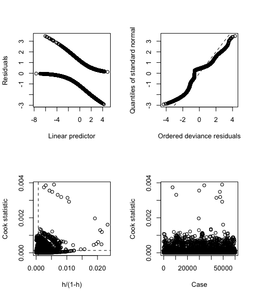

```r
library(boot)
glm.diag.plots(glm_model, glmdiag = glm.diag(glm_model))
```

بر اساس نمودار بالا مشاهده می کنیم که خطای ما توزیع مناسبی حول صفر ندارد. از طرفی از آنجا که باقیمانده ها بر روی خط فیت نشده اند، مقدار واریانس نیز ثابت نیست. همچنین مشاهده می کنیم که دیتاهایی هستند که خارج از بازه ی cook بوده و باعث خراب شدن مدل شده اند و حذف این داده ها به بهبود مدل کمک می کند.

۴. با استفاده از سه نمودار خروجی مدل را نسبت به داده واقعی ارزیابی کنید.

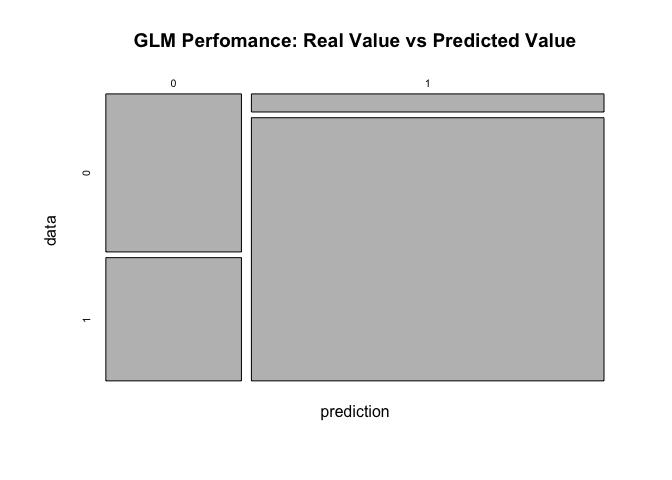

```r
death_num <- na.omit(death_num)

table(death_num$MannerOfDeath, ifelse(fitted(glm_model_new)>0.5,1,0)) %>%
  plot(xlab = "prediction", ylab = "data") %>%
  title(main = "GLM Perfomance: Real Value vs Predicted Value")
```

در این نمودار مشاهده می کنیم که تعداد داده هایی که درست(مثبت یا منقی) پیش بینی شده است از تعداد داده هایی که غلط پیش بینی شده اند بیشتر است. اما میزان خطای مدل ما کم نیست.

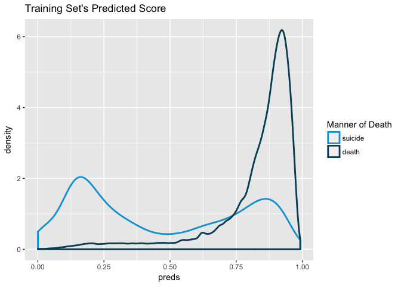

```r
library(ggplot2)
library(ggthemes)

death_num_pred = death_num %>% mutate(preds = predict(glm_model, type = 'response'))
ggplot( death_num_pred, aes( preds, color = as.factor(MannerOfDeath))) +
  geom_density( size = 1 ) +
  ggtitle( "Training Set's Predicted Score" ) +
  scale_color_economist( name = "Manner of Death", labels = c( "suicide", "death" ) )
```

در این نمودار مشاهده می کنیم که تقریبا بیشترین تراکم داده در هر گروه نزدیک به احتمال آن گروه قرار دارد، اما میزان همپوشانی دو نمودار زیاد است که این موضوع نشان دهنده ی خطای مدل ما می باشد.

برای بخش نمایش نمودار این سوال و سه سوال بعدی از فایل unbalanced_functions استفاده می شود.

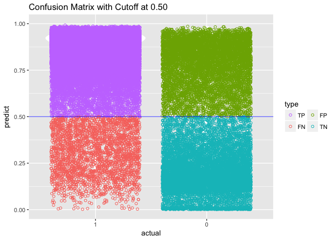

```r
source(file = "codes/unbalanced_functions.R")

cm_info = ConfusionMatrixInfo( data = death_num_pred, predict = "preds",
                               actual = "MannerOfDeath", cutoff = 0.5 )
cm_info$plot
```

در نمودار بالا مشاهده می کنیم که تعداد مقادیر درست پیش بینی شده، از مقادیر اشتباه بیشتر است، اما تعداد پیش بینی های اشتباه بسیار زیاد است که نشان می دهد که دقت مدل ما خیلی بالا نیست. از طرفی مقادیر پیش بینی شده نیست، عموما احتمالی نزدیک ۱ یا ۰ ندارند که این موضوع نیز باعث می شود که انتخاب مقادیر cutoff در دقت ما بسیار تاثیر داشته باشد و انتخاب cutoff دشوار شود.

۵. ابتدا ۲۰ درصد داده را به صورت تصادفی به عنوان تست در نظر بگیرید. مدل را با استفاده از ۸۰ درصد باقی مانده برازش دهید. با استفاده از پارامتر قطع ۰.۵ نتایج را برای داده تست پیش بینی کنید. سپس کمیت های زیر را محاسبه کنید.

- P: positive samples
- N: negative samples
- TP: true positive TP (eqv. with hit)
- TN: true negative (eqv. with correct rejection)
- FP: false positive (eqv. with false alarm, Type I error)
- FN: false negative (eqv. with miss, Type II error)
- Accuracy (ACC) ACC = (TP+TN)/(P+T)
- False positive rate (FPR): 1- TN/N
- True positive rate (TPR): TP/P

مشابه آنچه در کلاس گفته شد نمایشی از چهار کمیت TN, TP,FP,FN به همراه داده ها رسم نمایید.

```r
index = sample(x= 1:nrow(death_num),size = round(0.8*nrow(death_num)),replace = F)
train = death_num[index,]
train <- na.omit(train)

test =  death_num[-index,]
test <- na.omit(test)

glm_model = glm(MannerOfDeath~., family = binomial(link = 'logit'), data = train)

train$prediction  = predict(glm_model, newdata = train, type = "response")
test$prediction  = predict(glm_model, newdata = test, type = "response")
cutoff = 0.5
train <- train %>% mutate(get = ifelse(prediction < cutoff, 0, 1))
test <- test %>% mutate(get = ifelse(prediction < cutoff, 0, 1))

P <- test %>% filter(MannerOfDeath == 1) %>% nrow()
cat("P: ", P)
```

```
P:  8397
```

```r
N <- test %>% filter(MannerOfDeath == 0) %>% nrow()
cat("N: ", N)
```

```
N:  3209
```

```r
TP <- test %>% filter(MannerOfDeath == 1 & get == 1) %>% nrow()
cat("TP: ", TP)
```

```
TP:  7878
```

```r
TN <- test %>% filter(MannerOfDeath == 0 & get == 0) %>% nrow()
cat("TN: ", TN)
```

```
TN:  1757
```

```r
FP <- test %>% filter(MannerOfDeath == 0 & get == 1) %>% nrow()
cat("FP: ", FP)
```

```
FP:  1452
```

```r
FN <- test %>% filter(MannerOfDeath == 1 & get == 0) %>% nrow()
cat("FN: ", FN)
```

```
FN:  519
```

```r
ACC <- (TP + TN)/(P + N)
cat("Accuracy: ", ACC)
```

```
Accuracy:  0.830174
```

```r
FPR <- 1 - (TN/N)
cat("False Positive Rate: ", FPR)
```

```
False Positive Rate:  0.4524774
```

```r
TPR <- TP/P
cat("True Positive Rate: ", TPR)
```

```
True Positive Rate:  0.9381922
```

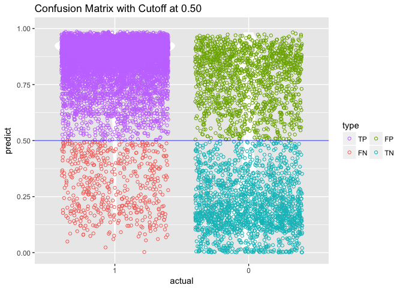

```r
cm_info = ConfusionMatrixInfo( data = test, predict = "prediction",
                               actual = "MannerOfDeath", cutoff = cutoff )
cm_info$plot
```

در نمودار بالا مشاهده می کنیم که تعداد مقادیر درست پیش بینی شده، از مقادیر اشتباه بیشتر است، اما تعداد پیش بینی های اشتباه بسیار زیاد است که نشان می دهد که دقت مدل ما خیلی بالا نیست. از طرفی مقادیر پیش بینی شده نیست، عموما احتمالی نزدیک ۱ یا ۰ ندارند که این موضوع نیز باعث می شود که انتخاب مقادیر cutoff در دقت ما بسیار تاثیر داشته باشد و انتخاب cutoff دشوار شود.

۶. نمودار صحت مدل (accuracy) را بر حسب مقادیر مختلف قطع برای داده تست رسم نمایید. کدام پارامتر قطع بالاترین صحت را در پیش بینی داراست؟

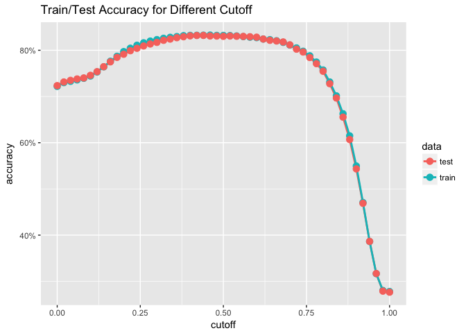

```r
accuracy_info = AccuracyCutoffInfo( train = train, test = test,
                                    predict = "prediction", actual = "MannerOfDeath" )
accuracy_info$plot
```

```r
accuracy_info$max_acc$accuracy
```

```
[1] 0.8328918
```

```r
cat("maximum accuracy is:", accuracy_info$max_acc$accuracy, " with cutoff:", accuracy_info$max_acc$cutoff)
```

```
maximum accuracy is: 0.8328918  with cutoff: 0.46
```

۷. نمودار ROC را برای داده های قسمت قبل رسم نمایید. همچنین نقطه مربوط به بهترین پارامتر قطع را مشخص نمایید.

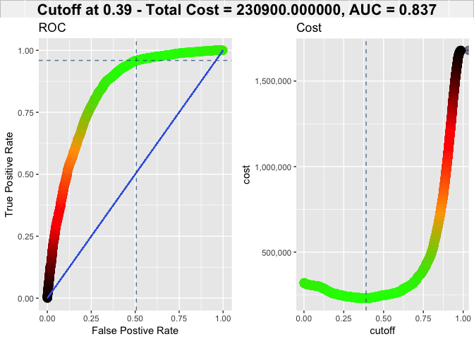

```r
cost_fp = 100
cost_fn = 200
roc_info = ROCInfo( data = cm_info$data, predict = "predict",
                    actual = "actual", cost.fp = cost_fp, cost.fn = cost_fn )
plot(roc_info$plot)
```

```r
cat("optimal cutoff value:", roc_info$cutoff, "and the corresponding true positive rate:",  roc_info$sensitivity, "and false positive rate:", 1 - roc_info$specificity)
```

```
optimal cutoff value: 0.3905747 and the corresponding true positive rate: 0.9592712 and false positive rate: 0.5063883
```

۸. با قرار دادن کمیت nfolds = 5 و با استفاده از H20 مدل مساله را بسازید و نتیجه حاصل را ارزیابی کنید.

در این مدل از داده هایی که بی تاثیر بودن آن ها را بدست آورده بودیم، استفاده نمی کنیم.

```r
library(h2o)

h2o.init()
```

[output not shown]

```r
y <- "MannerOfDeath"
x <- c("ResidentStatus", "edu", "AgeRecode27", "PlaceOfDeathAndDecedentsStatus",
       "InjuryAtWork", "MannerOfDeath", "MethodOfDisposition", "MaritalStatus",
       "ActivityCode", "PlaceOfInjury", "Sex", "RaceRecode3")

h_death_num <- as.h2o(death_num)
hglm = h2o.glm(y = y, x = x,
                training_frame = h_death_num, family="binomial", link = "logit", lambda = 0,
               compute_p_values = TRUE, nfolds = 5)
hglm
```

```
Model Details:
==============

H2OBinomialModel: glm
Model ID:  GLM_model_R_1524867406312_1
GLM Model: summary
    family  link regularization number_of_predictors_total
1 binomial logit           None                         18
  number_of_active_predictors number_of_iterations training_frame
1                          18                    5      death_num

Coefficients: glm coefficients
                            names coefficients std_error    z_value
1                       Intercept     0.266059  0.086019   3.093030
2           MethodOfDisposition.C     0.715672  0.025152  28.454059
3           MethodOfDisposition.D     1.098992  0.288254   3.812578
4           MethodOfDisposition.O    -0.485416  0.165966  -2.924799
5           MethodOfDisposition.U     0.416702  0.042562   9.790489
6                 MaritalStatus.M     0.243537  0.037103   6.563862
7                 MaritalStatus.S    -0.192704  0.037262  -5.171586
8                 MaritalStatus.U    -1.135422  0.111190 -10.211578
9                 MaritalStatus.W    -0.161976  0.063448  -2.552883
10                 InjuryAtWork.U     0.313946  0.052070   6.029319
11                 InjuryAtWork.Y    -1.540687  0.096025 -16.044720
12                          Sex.M     0.259987  0.028305   9.185300
13                 ResidentStatus    -0.161263  0.020901  -7.715436
14                            edu     0.218551  0.008109  26.950326
15                    AgeRecode27     0.092955  0.004202  22.123239
16 PlaceOfDeathAndDecedentsStatus     0.065283  0.005739  11.375921
17                   ActivityCode    -0.005554  0.001507  -3.685455
18                  PlaceOfInjury    -0.037107  0.001389 -26.705784
19                    RaceRecode3    -1.168706  0.014267 -81.918125
    p_value standardized_coefficients
1  0.001981                  0.631385
2  0.000000                  0.715672
3  0.000138                  1.098992
4  0.003447                 -0.485416
5  0.000000                  0.416702
6  0.000000                  0.243537
7  0.000000                 -0.192704
```

[output cut: 95 more lines]

```
---
                        mean           sd cv_1_valid cv_2_valid cv_3_valid
precision         0.83687973  0.004036343  0.8343956  0.8281965  0.8361879
r2                0.36745015 0.0039948053 0.36451975 0.35844156 0.37384188
recall             0.9536595 0.0020285523  0.9569802 0.95619494 0.95339644
residual_deviance   9520.405     140.2052   9540.611    9824.04   9497.066
rmse              0.35618812  0.001724571 0.35736024 0.35936326 0.35553235
specificity        0.5164981  0.011914689  0.5080695 0.48818183 0.52119166
                  cv_4_valid cv_5_valid
precision          0.8405122 0.84510636
r2                0.36761585  0.3728317
recall              0.948865  0.9528607
residual_deviance   9540.854   9199.453
rmse               0.3566921 0.35199264
specificity        0.5348765 0.53017104
```

۹. آیا ما میتوانیم سرویسی به قضات ارایه کنیم تا با استفاده از اطلاعات مرگ بتوانند موارد مشکوک به قتل را از خودکشی تفکیک دهند؟

خیر، زیرا همانطور که در مدل بالا دیدیم، میزان خطای این مدل ها کم نیست. از طرفی در مدل بالا می توانیم با دقت بالایی خودکشی هایی که واقعا خودکشی بوده اند را پیشبینی کنیم، اما دقت ما در مواردی که قتل بوده است اما خودکشی پیشبینی شده است بسیار کم است. به همین دلیل این روش (حداقل با این دقت) برای قضاوت گزینه ی مناسبی نیست. از طرفی این پیشبینی ها نوسان دارند، به طوری که دقت ما همواره مقدار ثابتی نیست و این موضوع نیز بر روی عدم اطمینان به این موضوع صحه می گذارد.